# Project 1 Client Report

Alvin Thomas

10/7/2019

# Introduction

[figure not shown]

The [Urban Ministries of Durham](http://www.umdurham.org/) (UMD) fights poverty and homeless by offering food, shelter, and a future to neighbors in need. Their mission is accomplished through three primary programs: a [community shelter](http://www.umdurham.org/what-we-do/shelter.html) to house homeless neighbors, a [community cafe](http://www.umdurham.org/what-we-do/cafe.html) that provides hot and cold meals three times a day, and a [food pantry and clothing closet](http://www.umdurham.org/what-we-do/food-pantry.html).

During the 2017-2018 [fiscal year](http://umdurham.org/assets/files/UMD_2018AnnualReport_Online.pdf), UMD provided 54,378 nights of shelter to homeless neighbors (792 unique individuals), served 248,028 meals through the community cafe, and provided clothing and groceries to over 500 households per month. Importantly, they ended homelessness for 243 individuals.

In collaboration with [Biostatistics 611](https://biodatascience.github.io/datasci611/), a course titled “Introduction to Data Science” at the University of North Carolina at Chapel Hill, UMD released a dataset of services provided.

# Study Aim

The purpose of this project is address how UMD’s core services have changed over time. We will focus on the food pantry and clothing closet services.

Specifically, our aim is to quantify changes in the distribution of food, clothing, school kits, hygiene kits, and diapers (2010-2017). We focus on more recent years since they may be more indicative of outcomes in the near future.

A sub-aim of this project is to understand the quality of the data available to UMD.

# Results

## Food Distribution

The amount of food delivered has increased over the years. There does not seem to be a clear visual signal of seasonal change.

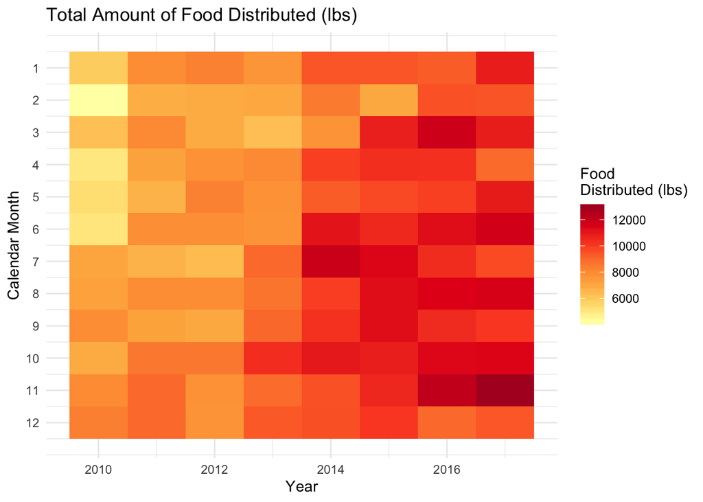

## Clothing Distribution

The amount of clothing delivered has changed over time. The peak year was 2014.

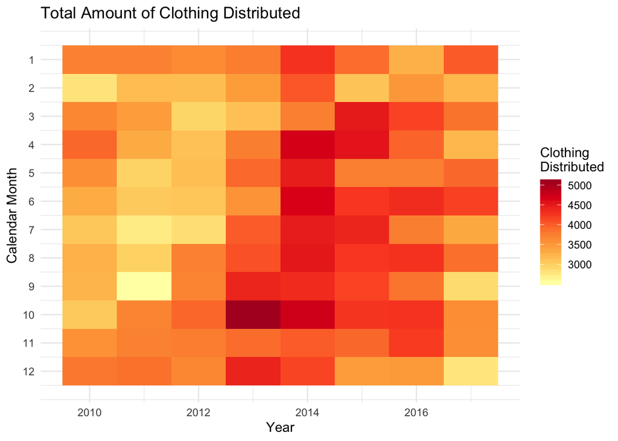

## School Kit Distribution

The quality of data on school kit distribution may be poor.

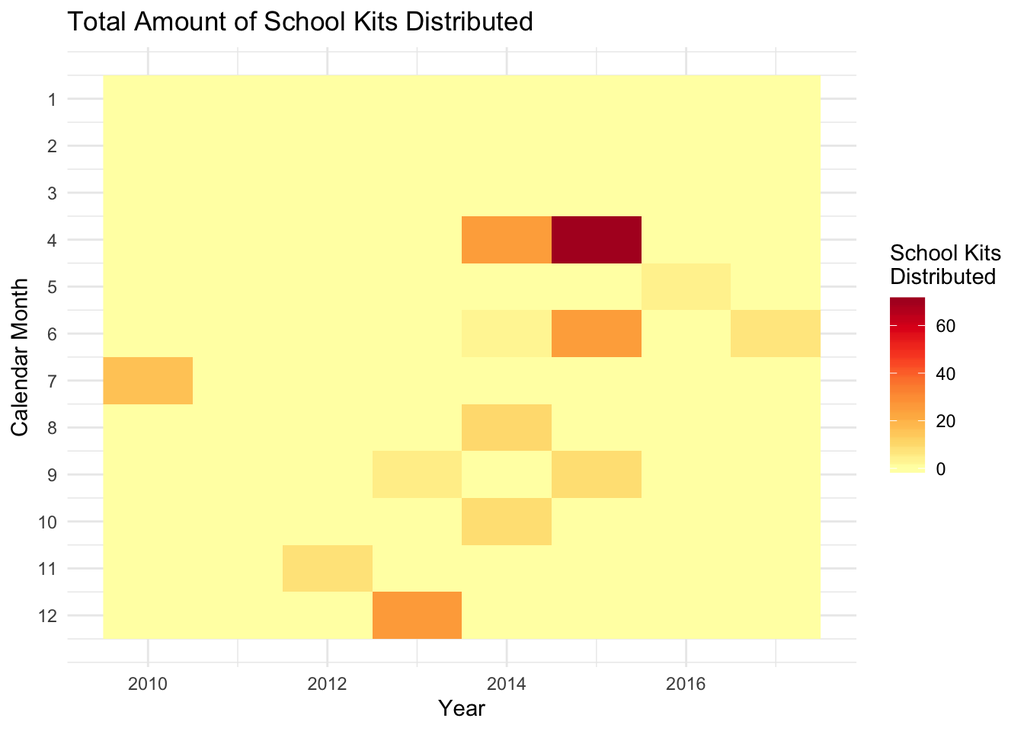

## Hygiene Kit Distribution

We know that hygiene kits are still being distributed, but the data capture on these events are poor. It appears that there have been almost no hygiene kits distributed since 2014, which we know to be false.

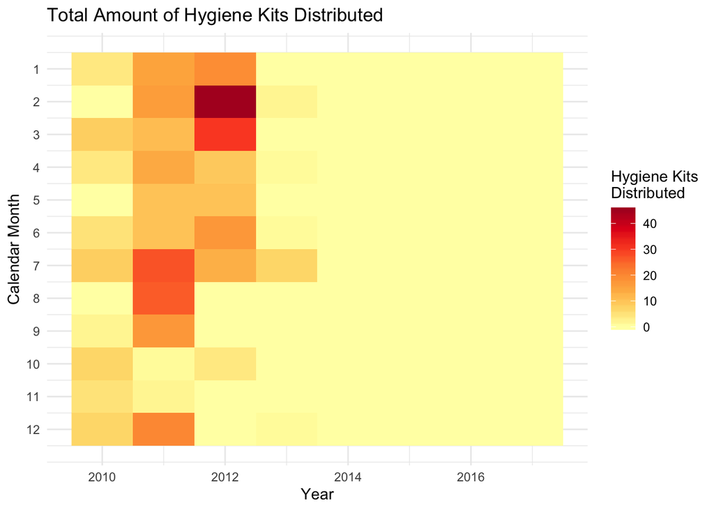

## Diaper Distribution

The quality of data on diaper distribution may be poor. There may be higher diaper distribution in the summer.

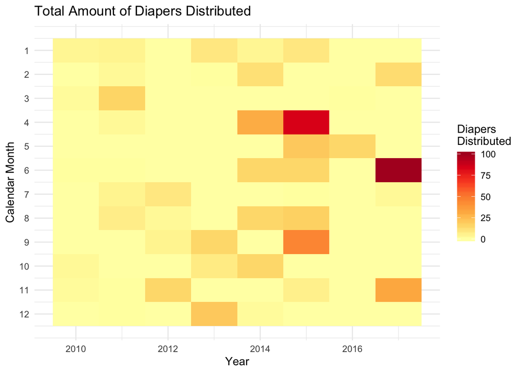

# Conclusion

The best data on changes over time in this UMD provided dataset are for food distribution. Food distribution has increased over time and does not seem to have strong seasonal variation.